# descenso_del_sella

# Análisis Descenso del Sella

Análisis de resultados históricos del Descenso Internacional del Sella.

### 1.Obtención de la información.

#### 1.1 Listado de vencedores y tiempos histórico (wikipedia).

#### 1.2 Extracción resultados última década de todos los participantes (pdfs).

#### 1.3 Extracción resultados 1970-2000 (pdfs imágenes).

#### 1.4 Confección tabla única con toda la información obtenida.

### 2.Exploración de datos inicial.

#### 1.Obtención de la información.

##### 1.1 Listado de vencedores y tiempos histórico (wikipedia).

Cargo los paquetes que voy a necesitar para el análisis:

```r
library(tidyverse)
library(rvest)
library(lubridate)
library(tabulizer)
```

En la wikipedia hay una tabla con los vencedores en categoría K2 de la prueba: https://es.wikipedia.org/wiki/Descenso_Internacional_del_Sella

Utilizo las funciones del paquete rvest para importar la información de la wikipedia. Importo toda la entrada de la wikipedia:

```r
descenso_wiki <- read_html('https://es.wikipedia.org/wiki/Descenso_Internacional_del_Sella')
# save(descenso_wiki, file = "descenso_wiki.Rdata")
# load(file = "descenso_wiki.Rdata")
```

Localizo las tablas y selecciono la tercera, que es donde están registrados todos los vencedores con sus respectivos tiempos. Asigno el data frame resultante a ‘vencedores_0’:

```r
vencedores_0 <- html_nodes(descenso_wiki, "table") %>% .[[3]] %>% html_table(header = TRUE)
```

Echo un vistazo al formato de la tabla:

```r
head(vencedores_0)
```

```
##              EXCURSIONES            EXCURSIONES
## 1                Edición                    Año
## 2                      I                   1930
## 3                     II                   1931
## 4 DESCENSOS PROVINCIALES DESCENSOS PROVINCIALES
## 5                Edición                    Año
## 6                    III                   1932
##                                       EXCURSIONES            EXCURSIONES
## 1                                       Ganadores              Municipio
## 2 Manés Fdez.- Alfonso Argüelles- Dionisio Huerta               Infiesto
## 3 Manés Fdez.- Alfonso Argüelles- Dionisio Huerta               Infiesto
## 4                          DESCENSOS PROVINCIALES DESCENSOS PROVINCIALES
## 5                                       Ganadores              Municipio
## 6                 César Sánchez Llano-Antón Durán            Ribadesella
##              EXCURSIONES
## 1                 Tiempo
## 2                   7 h.
## 3                  12 h.
## 4 DESCENSOS PROVINCIALES
## 5                 Tiempo
## 6                1:53:00
```

Tenemos que arreglar algún detalle de la tabla. Para empezar el nombre de las variables se encuentra en la primera fila de datos, apareciendo como nombres de las columnas el tipo de competición del inicio de la prueba: ‘EXCURSIONES’. Esto último ocurre varias veces a lo largo de la tabla. Cuando cambia el tipo de competición aparece antes una fila con el tipo repetido en cada columna y a continuación otra vez el nombre de las columnas.

Primero, cambio el nombre de las variables, eliminando tildes, la ‘ñ’ y las minúsculas:

```r
colnames(vencedores_0) <- c("edicion", "ano", "ganadores", "municipio", "tiempo")
```

Y segundo, elimino todas las filas que no recojan los resultados de la prueba. Para ello primero cambio el formato de la variable ‘Año’ a ‘numeric’.

```r
vencedores_0$ano <- as.numeric(vencedores_0$ano)
```

Al convertir a formato numérico la variable ‘ano’ R convierte a NA todo lo que no puede convertir en un número. Esto nos puede servir para identificar todas las filas que no nos interesan, quedándonos únicamente con las filas que en la variable ‘Año’ presentan un número.

```r
vencedores_0 <- vencedores_0 %>% filter(!is.na(ano))
```

Para recuperar la información del tipo de competición a lo largo de la historia del Descenso creo una nueva variable que la recoja. Utilizo la función ‘cut’ para crear un vector llamado ‘Tipo’ con los tipos de competición para cada rango de años:

```r
tipo <- cut(vencedores_0$ano, breaks = c(1929, 1931, 1934, 1950, Inf), labels = c("Excursión", "Provincial", "Nacional", "Internacional"))
```

Convierto el objeto creado en un data frame y lo uno a la tabla ‘vencedores_0’

```r
tipo <- as.data.frame(tipo)

vencedores_1 <- bind_cols(vencedores_0, tipo)
```

La variable ‘Municipio’ a partir de que la competición se convierte en internacional no recoge el municipio origen de los participantes sino el país.

```r
summary(as.factor(vencedores_1$municipio))
```

```
##    Alemania   Australia     Bélgica   Cantabria   Dinamarca      España
##           1           1           3           1           6          47
##       Gijón    Infiesto  Inglaterra      Italia    Portugal Ribadesella
##           5           2           2           1           1           5
##   Sudáfrica      Suecia       Suiza
##           2           2           1
```

Arreglo esto creando una nueva variable ‘pais’ donde sólo quede registrado el país y elimino la variable ‘municipio’

```r
vencedores_1 <- vencedores_1 %>% mutate(pais = ifelse(ano < 1951, "España", municipio))
vencedores_1$municipio <- NULL
```

La variable “tiempo” recoge el tiempo empleado por cada ganador en horas, minutos y segundos. Pero antes de poder utilizar esta información hay que realizar alguna modificación a su formato.

Primero, en la tabla de la wikipedia el autor ha incluido un símbolo “®” a la derecha de los tiempos que supusieron un récord en su momento. Eliminamos este símbolo,

```r
vencedores_1$tiempo <- str_replace(vencedores_1$tiempo, "®", "" )
```

Los tiempos de los dos primeros años están en otro formato. Sustituimos sus valores por los correspondientes en h:mm:ss

```r
vencedores_1$tiempo[[1]] <- "7:00:00"
vencedores_1$tiempo[[2]] <- "12:00:00"
```

Y falta el tiempo final de 2017. Lo añadimos

```r
vencedores_1$tiempo[[80]] <- "1:07:13"
```

Además hay algún error en el formato del resto de tiempos, en alguna ocasión los “:” son sustituidos por “-” o “.”. Lo solucionamos sustituyendo en esta columna todos los “-” y “.” por “:”.

```r
vencedores_1$tiempo <- str_replace(vencedores_1$tiempo, "-", ":" )
vencedores_1$tiempo <- str_replace(vencedores_1$tiempo, "\\.", ":" )
vencedores_2 <- vencedores_1
```

Finalmente convertimos la variable de “character” formato “hora” con la función “hms” del paquete “lubridate”

```r
vencedores_2$tiempo <- hms(vencedores_2$tiempo)
```

Probamos a hacer un primer gráfico.

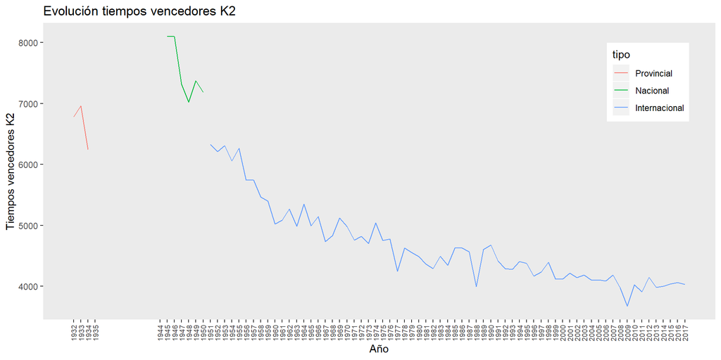

```r
vencedores_2$tiempo <- as.duration(vencedores_2$tiempo)
vencedores_3 <- vencedores_2 %>% filter(tipo != "Excursión")
vencedores_4 <- vencedores_3 %>% mutate(fecha = paste(ano, "-", "08", "-", "01"))
vencedores_4$fecha <- ymd(vencedores_4$fecha)
ggplot(data = vencedores_4, aes(x = ano, y = as.numeric(tiempo), color = tipo)) + geom_line() +
  labs(title = "Evolución tiempos vencedores K2", y = "Tiempos vencedores K2",  x = "Año") +
  theme(axis.text.x=element_text(angle=90,hjust=1,vjust=0.5, size = 7)) +
  scale_x_continuous(breaks = vencedores_4$ano) +
  theme(panel.grid.major = element_blank(), panel.grid.minor = element_blank()) +
  theme(legend.position = c(0.9, 0.8))
```

```r
 # Otra posibilidad: facet_wrap(~tipo, ncol = 1, scales = "free_x")
```

##### 1.2 Extracción resultados última década de todos los participantes (pdfs).